# Populations isolées

- Show All Code
- Hide All Code
- View Source

## Le modèle de Malthus

Nous considérons le modèle proposé par Malthus (1798) :
$$\dot x = (n-m)x,
\tag{1}$$
avec $n$ le taux de natalité, et $m$ le taux de mortalité.

### Préliminaires

Pour simuler ce modèle, c’est à dire intégrer numériquement les solutions au problème de Cauchy correspondant à l’Equation 1 avec $x(0)=x_0\geq0$, nous allons utiliser les routines de `DifferentialEquations.jl` avec la méthode par défaut. Nous utiliserons aussi le package `Plots.jl` pour les représentations graphiques[^1].

<sup>1</sup> si vous n’avez jamais installé un package, il faudra commencer par le faire avant de pouvoir l’utiliser…

```julia
using DifferentialEquations
using Plots
```

### Conditions initiales, paramètres et temps

Nous définissions la condition initiale de la simulation :

```julia
x0 = 0.1
```

Nous définissons les paramètres, et les encapsulons dans un vecteur de paramètres :

```julia
n = 3.0     # natalité
m = 2.0     # mortalité
par_malthus = [n, m] # packing in an array
```

Enfin, les propriétés du temps d’intégration :

```julia
tspan = (0.0, 10.0)
tstep = 0.1
```

### Système dynamique

On définit le modèle comme une fonction renvoyant la dérivée de $x$ en fonction de l’état (`u` est la notation pour `DifferentialEquations.jl`), de paramètres (`p`), et du temps (`t`). L’ordre des arguments est important, c’est sous cette forme que les routines d’intégration attendent le modèle.

```julia
function malthus(u, p, t)
    n, m = p                # unpacking
    x = u                # use x notation
    return dx = (n-m)x      # return derivative
end
```

**Note**

L’ordre des arguments `u, p, t` est important pour le solver de `DifferentialEquations.jl`.

### Intégration

On commence par définir le problème de Cauchy à intégrer, comme un `ODEProblem` avec arguments: le modèle, la condition initiale, les bornes d’intégration, les paramètres ainsi que l’option `saveat = tstep` permettant de récupérer la solution tout les `tstep` pas de temps (il y a plein d’options de sortie de l’intégration, dont même une fonction du temps !)

```julia
prob_malthus = ODEProblem(
    malthus,          # modèle
    x0,               # condition initiale
    tspan,            # tspan
    par_malthus;      # paramètres
    saveat = tstep,   # keyword argument, option de sortie
)
```

On intègre le modèle via `solve`, défini par `DifferentialEquations.jl` pour des `struct` de type `ODEProblem` :

```julia
sol_malthus = solve(prob_malthus)
```

Le type de solution renvoyé par le solveur est assez complexe et comprend de nombreux champs informatifs sur le calcul. On peut accéder au temps de simulation via `sol_malthus.t` :

```julia
first(sol_malthus.t, 3)
```

```
3-element Vector{Float64}:
 0.0
 0.1
 0.2
```

ainsi qu’aux valeurs de la variable $x$ calculées le long du temps via `sol_matlhus.u` :

```julia
first(sol_malthus.u, 3)
```

```
3-element Vector{Float64}:
 0.1
 0.1105170918098962
 0.12214028021690748
```

Même si ce n’est pas indispensable, il est possible de transformer la solution renvoyée facilement en `DataFrame`, qui peut permettre des manipulations plus faciles.

```julia
using DataFrames

sol_malthus = DataFrame(sol_malthus)
rename!(sol_malthus, :timestamp => :time, :value => :x)
```

**Note**

remarquez la fonction `rename!` qui modifie en place le dataframe. Par convention les fonctions dont le nom finit par `!` modifient leur argument en place.

si bien que :

```julia
first(sol_malthus, 3)
```

3×2 DataFrame

| Row | time Float64 | x Float64 |
| --- | --- | --- |
| 1 | 0.0 | 0.1 |
| 2 | 0.1 | 0.110517 |
| 3 | 0.2 | 0.12214 |

### Représentation graphique

On peut représenter graphiquement la simulation de la croissance de la population au cours du temps (ici via le dataframe).

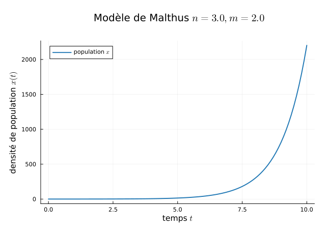

```julia
plot(
    sol_malthus.time,                   # abscisses
    sol_malthus.x;                      # ordonnées
    palette = :tab10,                   # palette de couleurs
    linewidth = 2,
    title = "\n Modèle de Malthus \$n=$n, m=$m\$",
    label = "population \$x\$",
    ylabel = "densité de population \$x(t)\$",
    xlabel = "temps \$t\$",
    margin = .5Plots.cm,
    topmargin = 1Plots.cm,
)
```

**Note**

Les titres et autres chaînes de caractères peuvent utiliser des formules LaTeX via `\$`, e.g. `"\$x\$"`.

La notation `"$m"` accède à la valeur du paramètre `m` et la renvoit dans la chaine de caractères.

## Le modèle logistique

Nous considérons ici le modèle “logistique” proposé par Verhulst (1838) :

$$\dot x = r x \left(1-\frac{x}{K}\right),
\tag{2}$$
avec $r$ le taux de croissance intrinsèque de la population et $K$ la capacité de charge de l’environnement.

Il n’y a pas de difficulté particulière par rapport aux simulations précedentes. On va réutiliser la condition initiale et les paramètres de temps définis précédemment.

Il faut cependant définir les paramètres du modèle Equation 2 :

```julia
r = 1.0      # natalité
K = 10.0     # mortalité
par_logistic = [r, K] # packing
```

ainsi que le nouveau système dynamique :

```julia
function logistic(u, p, t)
    r, K = p            # unpacking
    x = u            # use x notation
    return dx = r*x*(1-x/K)    # return derivative
end
```

et le problème de Cauchy correspondant :

```julia
prob_logistic = ODEProblem(
    logistic,         # modèle
    x0,               # condition initiale
    tspan,            # tspan
    par_logistic;     # paramètres
    saveat = tstep,   # option de sortie
)
```

On simule et on transforme la solution en dataframe :

```julia
sol_logistic = solve(prob_logistic)

sol_logistic = DataFrame(sol_logistic)
rename!(sol_logistic, :timestamp => :time, :value => :x)
```

On trace la solution, en rajoutant les équilibres stable ($x=K$) et instable ($x=0$) :

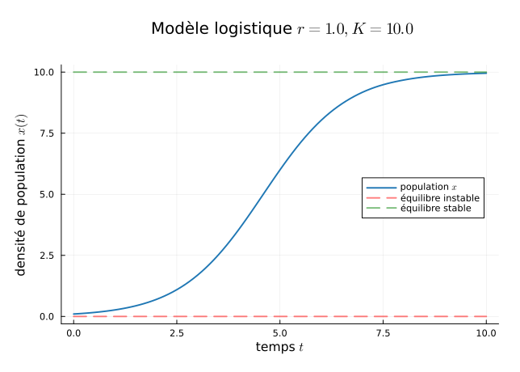

```julia
# solution
plot(
    sol_logistic.time,
    sol_logistic.x;
    palette = :tab10,
    linewidth = 2,
    title = "\n Modèle logistique \$r=$r, K=$K\$",
    label = "population \$x\$",
    legend = :right,
    ylabel = "densité de population \$x(t)\$",
    xlabel = "temps \$t\$",
    margin = .5Plots.cm,
    topmargin = 1Plots.cm,
)

# équilibre 0
plot!(
    sol_logistic.time,
    zeros(length(sol_logistic.time));
    color = "red",
    linewidth = 2,
    linestyle = :dash,
    linealpha = .5,
    label = "équilibre instable",
)

# équilibre K
plot!(
    sol_logistic.time,
    ones(length(sol_logistic.time)).*K;
    color = "green",
    linewidth = 2,
    linestyle = :dash,
    linealpha = .5,
    label = "équilibre stable",
)
```

**Note**

Remarquez l’utilisation de `plot!` qui modifie en place la première figure en rajoutant des éléments (ici les équilibres et leurs labels).

## Effets Allee

On s’intéresse à un modèle de dynamique de population avec “effets Allee forts”, souvent attribué à Gruntfest, Arditi, and Dombrovsky (1997)[^2] :

<sup>2</sup> mais de nombreuses variations de cette forme polynomiale existent dans la littérature depuis Bazykin (1985)

$$\dot x = r x \left(\frac{x}{\epsilon}-1\right)\left(1-\frac{x}{K}\right),
\tag{3}$$
avec $r$ le taux de croissance intrinsèque de la population (par analogie avec la logistique), $K$ la capacité de charge de l’environnement et $\epsilon$ le seuil en dessous duquel la population n’est pas viable (‘seuil de Allee’).

Nous souhaitons illustrer la bistabilité caractéristique du comportement de ce modèle à partir de la simulation depuis plusieurs conditions initiales.

Commençons par définir le modèle et les paramètres (en conservant les $r$ et $K$ précédents):

```julia
epsilon = 2                 # seuil de Allee
par_allee = [r, K, epsilon] # packing
tspan_allee = (0.0, 3.0)

function allee(u, p, t)
    r, K, epsilon = p        # unpacking
    x = u                 # use x notation
    return dx = r*x*(x/epsilon - 1)*(1 - x/K)     # derivative
end
```

Nous définissons une fonction qui réalise une simulation en un seul appel depuis une condition initiale $x_0$ :

```julia
function int_allee(x0, tspan = tspan_allee, param = par_allee)
    prob_allee = ODEProblem(
        allee,            # modèle
        x0,               # condition initiale
        tspan,            # tspan
        param;            # paramètres
        saveat = tstep,   # option de sortie
        )

    sol_allee = solve(prob_allee)
    sol_allee = DataFrame(sol_allee)
    rename!(sol_allee, :timestamp => :time, :value => :x)

    return sol_allee
end
```

**Note**

La fonction `int_allee` comporte un nombre d’arguments variable: `int_allee(x0)` renverra la solution avec les arguments `tspan` et `param` à leurs valeurs par défaut (ce sont des *vararg*); c’est le même appel que `int_allee(x0, tspan_allee, par_allee)`.

Nous définissons un vecteur de conditions initiales différentes :

```julia
x0step = 1.35
x0vec = x0step:x0step:K     # range de valeur
```

Finalement on réalise la figure. La stratégie diffère un peu de ce qui a été vu ci-dessus. Nous commençons par initier un graphique `fig`, et faisons une boucle `for` pour tracer chacune des simulations correspondant aux différentes conditions initiales[^3] :

<sup>3</sup> la palette de couleur est accessoire, juste pour l’esthétique

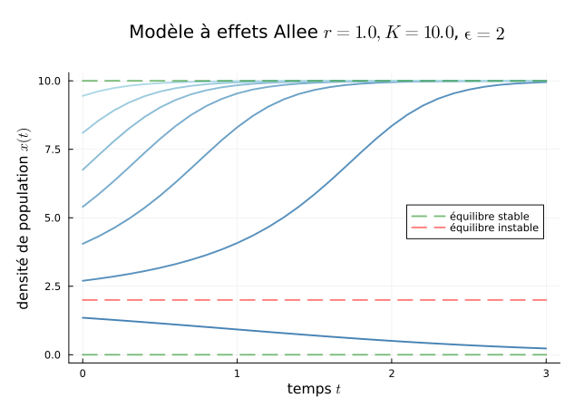

```julia
# custom color palette
init_cgrad = palette([:steelblue, :lightblue], length(x0vec))

# initialisation du graphique
fig = plot(;          # on initie uniquement le graphique
    palette = init_cgrad,
    title = "\n Modèle à effets Allee \$r=$r, K=$K\$, \$ϵ=$epsilon\$",
    legend = :right,
    ylabel = "densité de population \$x(t)\$",
    xlabel = "temps \$t\$",
    margin = .5Plots.cm,
    topmargin = 1Plots.cm,
    )

# boucle de plot avec intégration pour differentes conditions initiales
for x0 in x0vec         # x0 parcourt l'array x0vec
    plot!(
        fig,              # on modifie fig
        int_allee(x0).time, # abscisses
        int_allee(x0).x;    # ordonnées
        linewidth = 2,      # keyword arguments après ;
        label = "",
    )
end

# équilibre 0
plot!(
    fig,
    int_allee(0).time,
    zeros(length(int_allee(0).time));
    color = "green",
    linewidth = 2,
    linestyle = :dash,
    linealpha = .5,
    label = "équilibre stable",
)

# équilibre epsilon
plot!(
    fig,
    int_allee(0).time,
    ones(length(int_allee(0).time)).*epsilon;
    color = "red",
    linewidth = 2,
    linestyle = :dash,
    linealpha = .5,
    label = "équilibre instable",
)

# équilibre K
plot!(
    fig,
    int_allee(0).time,
    ones(length(int_allee(0).time)).*K;
    color = "green",
    linewidth = 2,
    linestyle = :dash,
    linealpha = .5,
    label = "",
)

display(fig)      # actually shows the plot P
```

On peut sauvegarder la figure dans différents formats (e.g. png, pdf) :

```julia
savefig(fig, "dyn_allee.pdf")
savefig(fig, "dyn_allee.png")
```

Passons aux populations exploitées.

## References

Bazykin, A. D. 1985. *Mathematical Biophysics of Interacting Populations*. Nauka, Moscow (in Russian).

Gruntfest, Y., R. Arditi, and Y. Dombrovsky. 1997. “A Fragmented Population in a Varying Environment.” *Journal of Theoretical Biology* 185: 539–47.

Malthus, T. R. 1798. *An Essay on the Principle of Population*. J. Johnson.

Verhulst, P. F. 1838. “Notice Sur La Loi Que La Population Poursuit Dans Son Accroissement.” *Correspondance Mathématique Et Physique* 10: 113–21.